# Exemple d’EDA - éruptions d’un geyser

Les données dans le fichier faithful représentent les délais entre éruptions et les durées des éruptions d’un geyser dans le parc Yellowstone aux USA. Nous allons examiner la distribution des ces données à l’aide des graphiques et des statistiques de base. C’est une étape préalable obligatoire avant toute analyse et modélisation statistique

```r
help(faithful)
data(faithful)
attach(faithful)
summary(eruptions)
```

```
   Min. 1st Qu.  Median    Mean 3rd Qu.    Max.
  1.600   2.163   4.000   3.488   4.454   5.100
```

```r
fivenum(eruptions) # résumé à 5 nombres de Tukey
```

```
[1] 1.6000 2.1585 4.0000 4.4585 5.1000
```

Nous pouvons calculer les statistiques de base selon nos besoins.

```r
mean(eruptions)
```

```
[1] 3.487783
```

```r
median(eruptions)
```

```
[1] 4
```

```r
min(eruptions)
```

```
[1] 1.6
```

```r
range(eruptions)
```

```
[1] 1.6 5.1
```

```r
quantile(eruptions)
```

```
     0%     25%     50%     75%    100%
1.60000 2.16275 4.00000 4.45425 5.10000
```

```r
var(eruptions) # variance
```

```
[1] 1.302728
```

```r
sqrt(var(eruptions)) # écart type
```

```
[1] 1.141371
```

Les graphiques tige et feuilles donnent une bonne idée de la distribution. L’histogramme est meilleur pour des grandes ensembles de données.

```r
stem(eruptions)
```

```
  The decimal point is 1 digit(s) to the left of the |

  16 | 070355555588
  18 | 000022233333335577777777888822335777888
  20 | 00002223378800035778
  22 | 0002335578023578
  24 | 00228
  26 | 23
  28 | 080
  30 | 7
  32 | 2337
  34 | 250077
  36 | 0000823577
  38 | 2333335582225577
  40 | 0000003357788888002233555577778
  42 | 03335555778800233333555577778
  44 | 02222335557780000000023333357778888
  46 | 0000233357700000023578
  48 | 00000022335800333
  50 | 0370
```

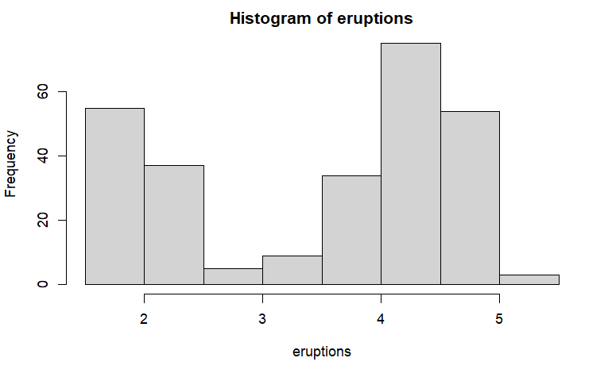

```r
hist(eruptions)
```

```r
# classes plus petites, tracé de la densité
hist(eruptions, seq(1.6, 5.2, 0.2), prob=TRUE) ;
lines(density(eruptions, bw=0.1))
```

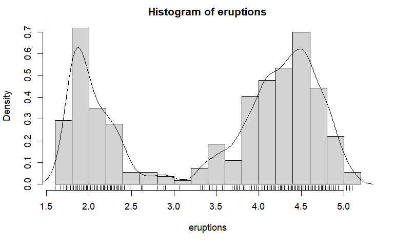

```r
rug(eruptions) # les données elles-même
```

Des tracés de densité plus sophistiqués sont obtenus avec *density*. La largeur de bande *(bw)* est choisie par tâtonnement parce que la valeur par défaut donne trop de lissage. Nous pouvons tracer la fonction de répartition empirique à l’aide de la fonction **ecdf** définie par

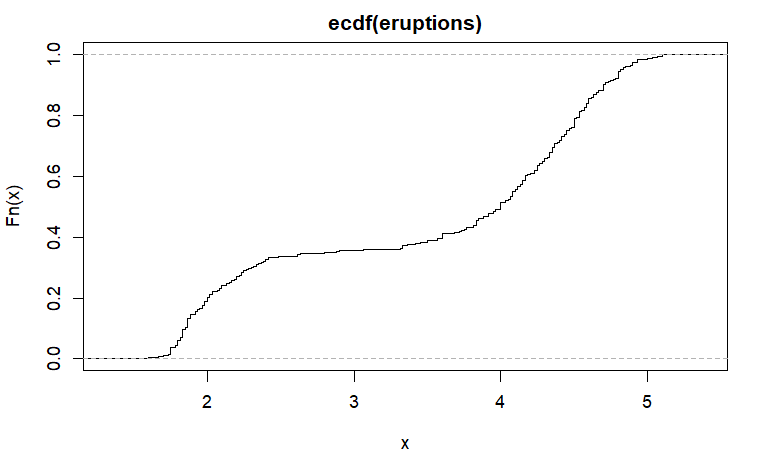

```r
##install.packages("stepfun")
##library(stepfun)
plot(ecdf(eruptions), do.points=FALSE, verticals=TRUE)
```

La distribution est loin de quelque chose de standard. Mais nous pouvons isoler les éruptions autour de la mode de droite qui sont de durée plus grande que 3 minutes. Nous ajustons une distribution normale que nous superposons sur le cdf.

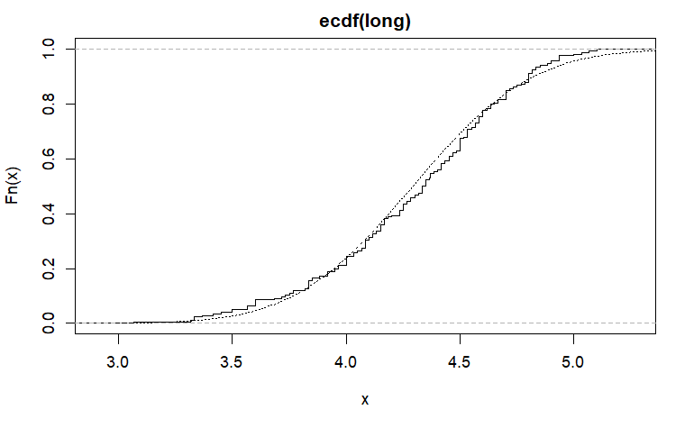

```r
long <- eruptions[eruptions > 3]
plot(ecdf(long), do.points=FALSE, verticals=TRUE)
x <- seq(3, 5.4, 0.01)
lines(x, pnorm(x, mean=mean(long), sd=sqrt(var(long))), lty=3)
```

Un graphique de quantiles peut nous aider.

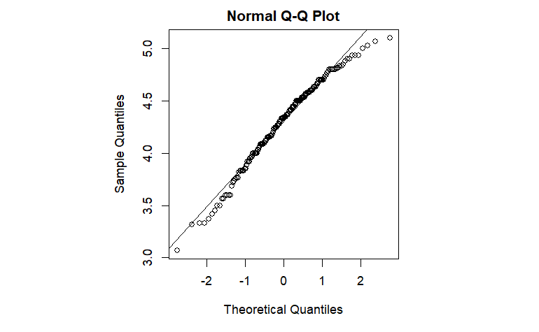

```r
par(pty='s') # tracé carré
qqnorm(long) ; qqline(long)
```

Il montre une ajustage raisonnable, mais la queue droite est plus courte qu’une distribution normale. Nous comparons avec des données simulées d’une distribution-t

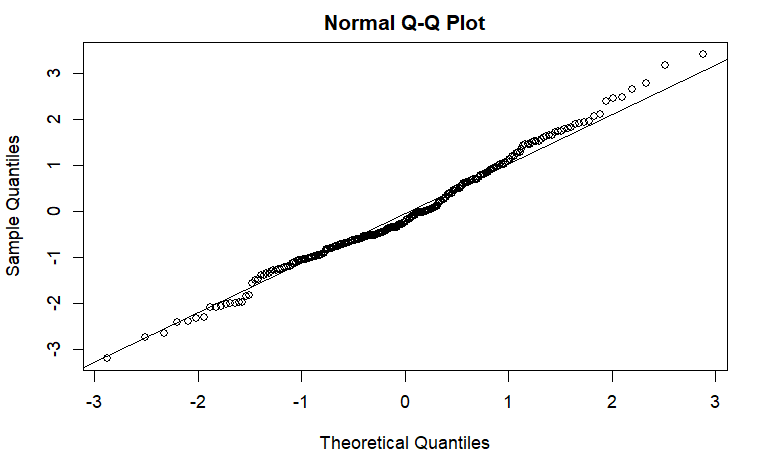

```r
x <- rt(250, df=5)
qqnorm(x) ; qqline(x)
```

qui normalement (étant un échantillon aléatoire) montre des queues plus longues qu’attendues pour une loi normale. Nous pouvons faire un graphique quantile contre la distribution t par

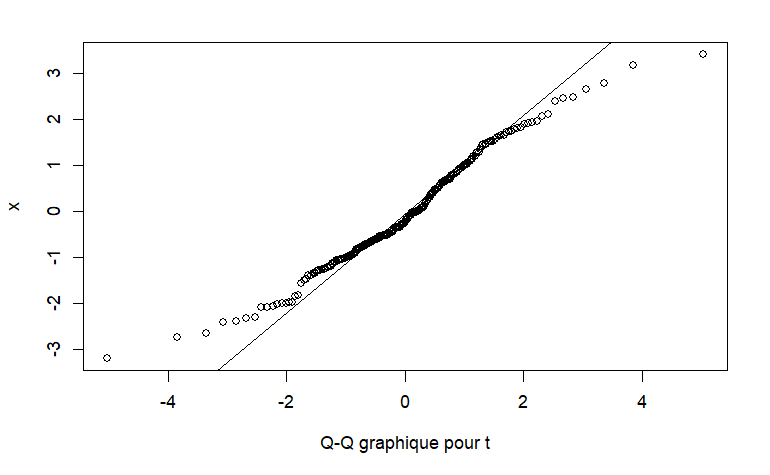

```r
qqplot(qt(ppoints(250), df=5), x, xlab="Q-Q graphique pour t")
qqline(x)
```

```r
library(ctest)
```

[output not shown]